—Comp title: “Modelling Rebalance Parameteres” author: “Karl Polen” date: “June 6, 2019” output: html_document: keep_md: TRUE —

Most experts recommend periodic rebalancing of a portfolio. The advantages of rebalancing including maintaining a portfolio at target risk parameters and potential gains through an enforced “buy low/sell high” discipline. The tradeoff comes with transaction costs and, if momentum is a market feature, risks of transacting too early causing losses in down trending markets or missing gains in up trending markets.

Vanguard conducted a helpful study of this concluding, in typical Vanguard fashion, that less is more. They find rebalancing about once a year captures the benefit and avoids higher costs of increased frequency. The study is found [here](https://www.vanguard.com/pdf/icrpr.pdf).

We will update this work with more recent data (the Vanguard study uses data ending in 2009) and will consider if trend analysis is beneficial. We will model a 60/40 portfolio of stocks bonds. Our objective is to model rebalancing considering transaction costs. We will review rebalance periods, rebalance bands and trend parameters. We don’t look at taxes assuming a tax free institutional investor. *Taxes are major consideration for individual investors and this analysis only applies to the simpler situation of a tax free institutional investor.*

## Testing with ACWI global stock index and BBG Agg

First, we will model using the ACWI global stock index. We will use all available data for the index which commenced in 2001.

### Analysis of rebalance time frames

We will compare rebalance results with rebalance at arbitrary time frames of buy/hold (never rebalance), annual, quarterly and monthly.

We benchmark performance and cost to a monthly costless rebalance which is the customary way for calculating benchmarks.

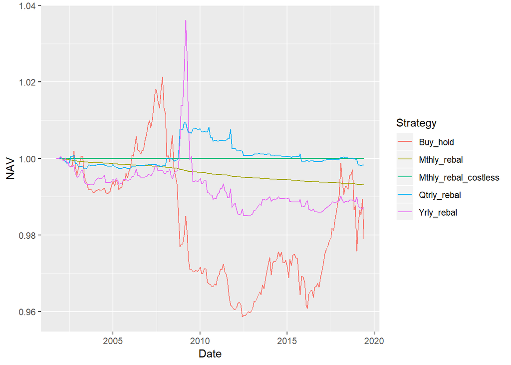

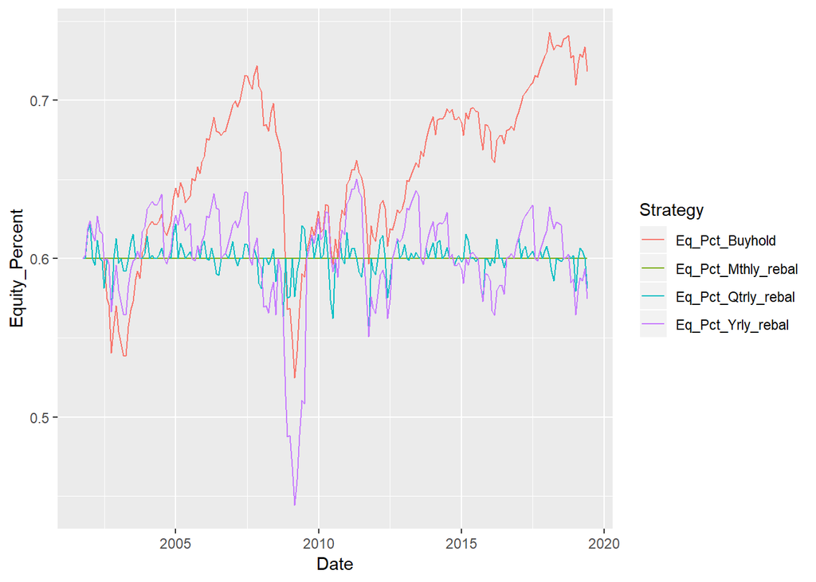

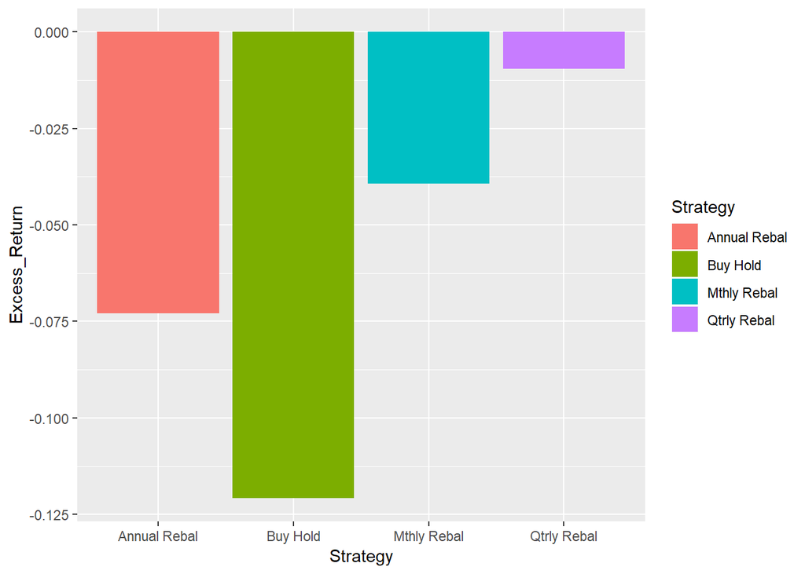

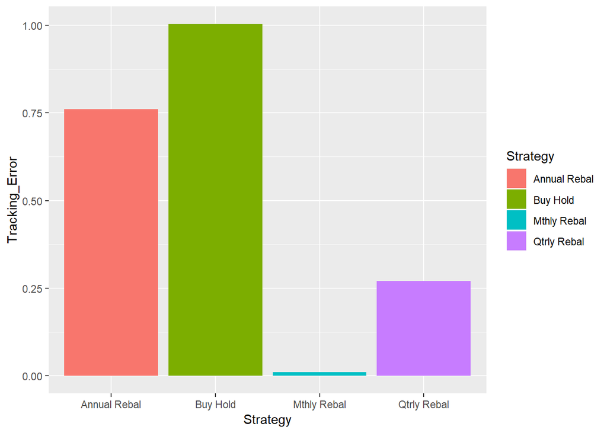

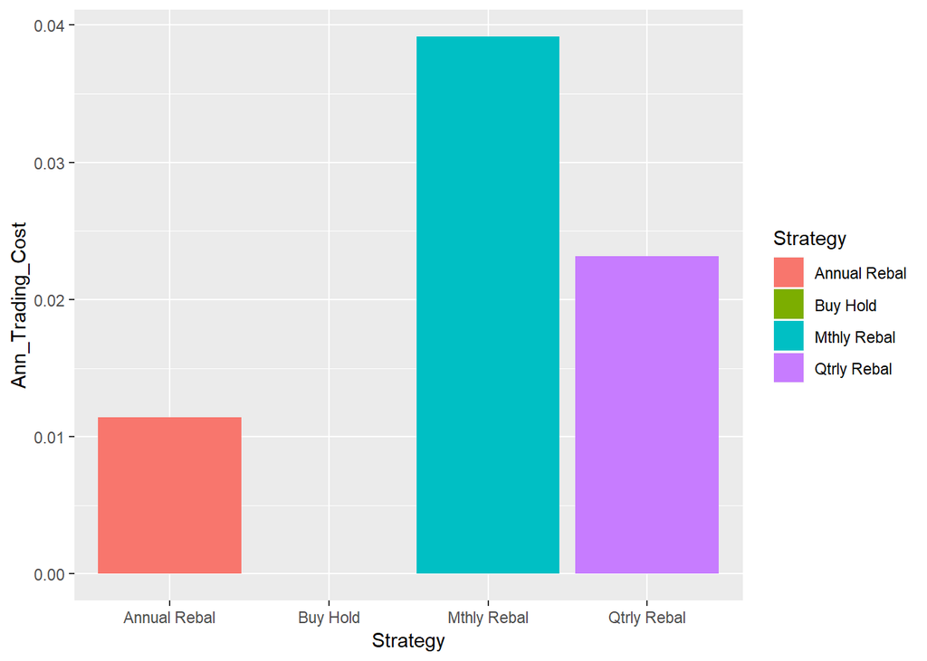

### Rebalance bands

Now we will consider a rebalance methodology where the rebalance decision is based on variation from target weight and only rebalance if the portfolio weight variance exceeeds a target amount. We will test 2%, 5% and 10% permitted variance.

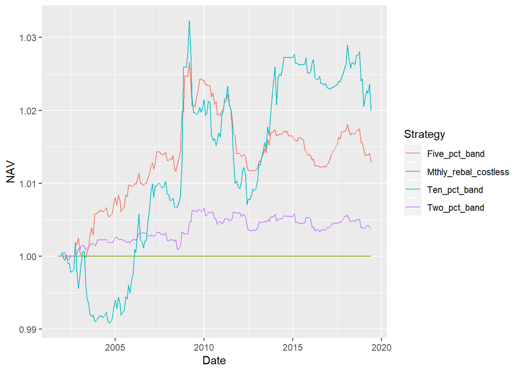

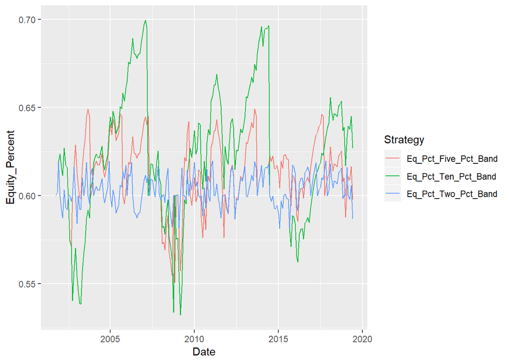

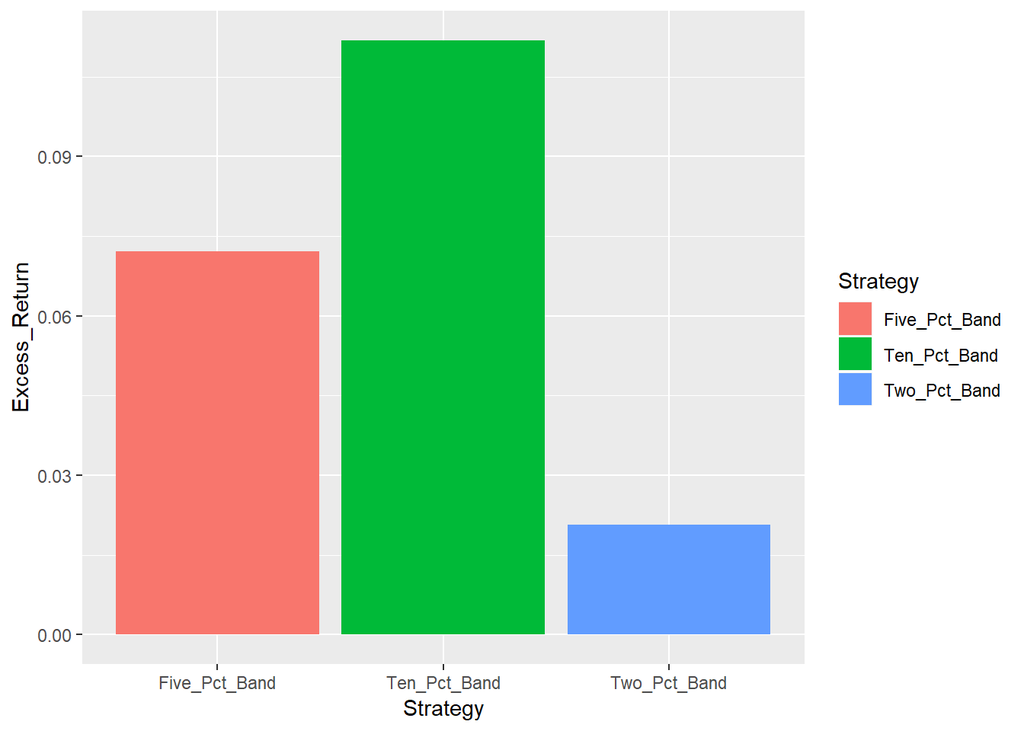

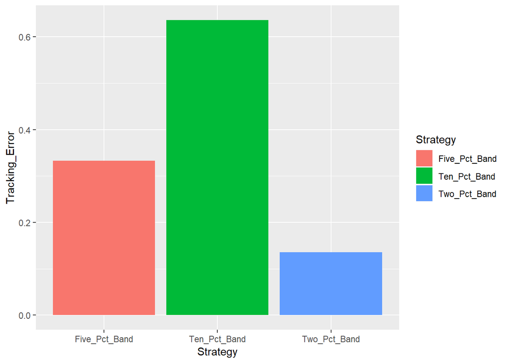

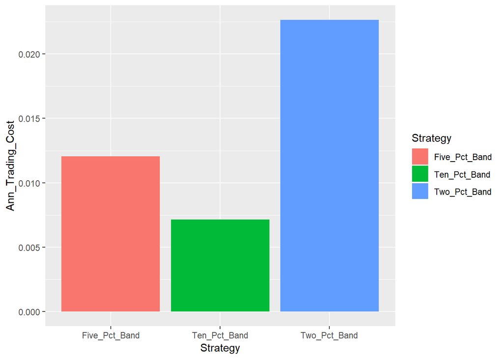

### Rebalance bands with a momentum filter

Now we repeat the rebalance bands analysis but with a 3 month momentum. If you are overweight stocks and you have 3 month momentum > 1, don’t rebalance. Same for downside.

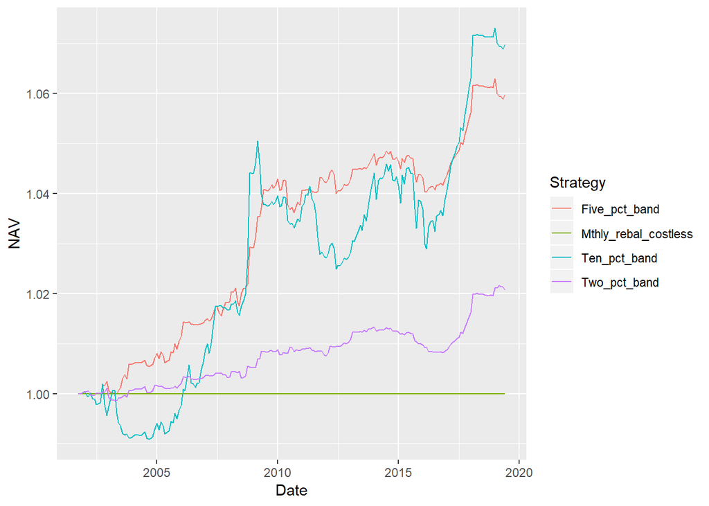

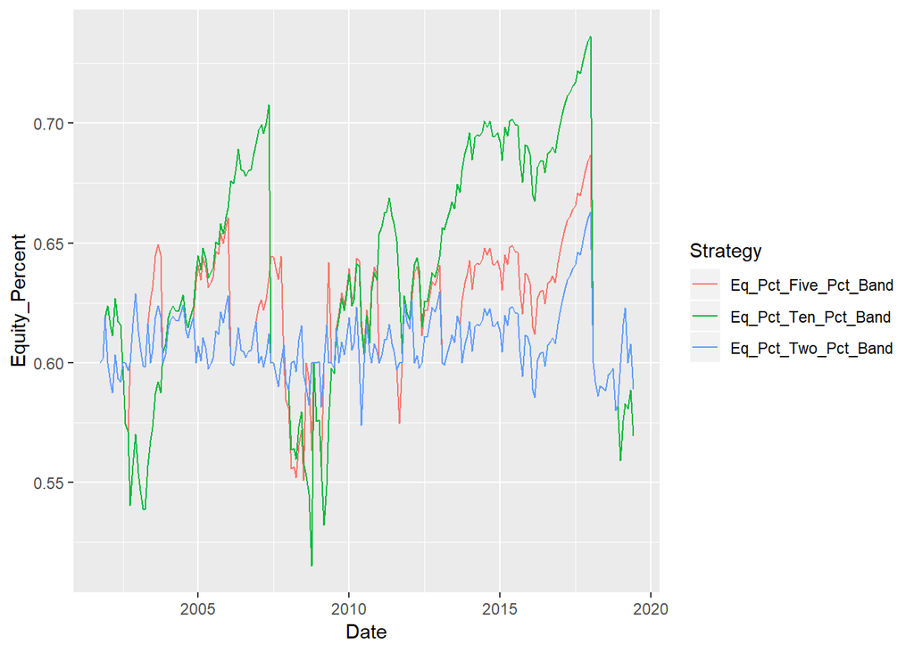

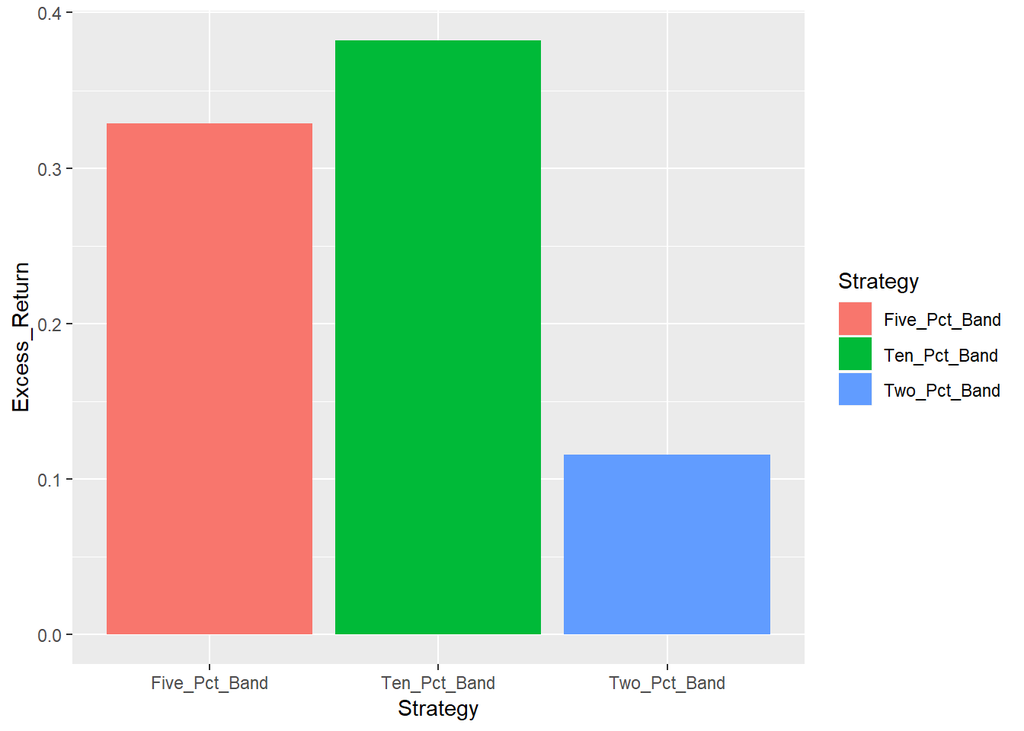

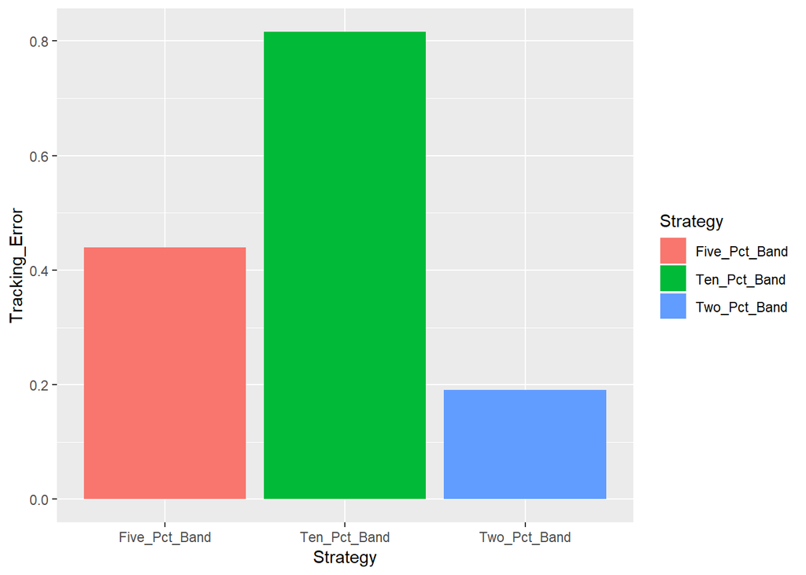

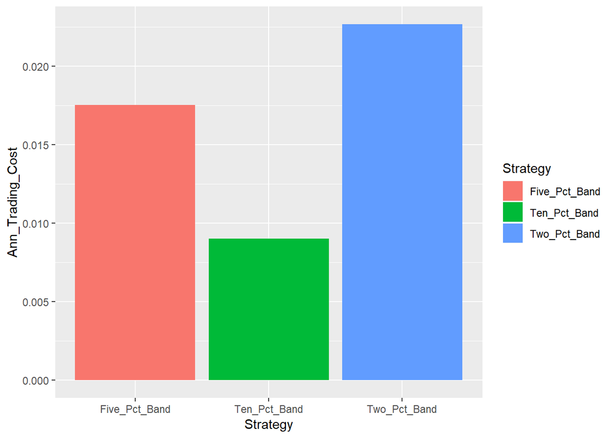